# 3_10 Impact of DNA methylation loss on Parhyale embryogenesis

# 4 Differential gene expression (DGE) analysis

## 4.1 Comapring embryos treated with DMSO or 5AZA for 12 hrs and sequenced at 12 hrs of development

````r
```r
library(tidyverse)
library(pheatmap)
library(RColorBrewer)
library(data.table)
library(ggpubr)
library(dcGOR)
library(ggrepel)
````

Summarise results

```r
dds_DMSOvs5AZA_12hrs_filtered <- comp_DMSOvs5AZA_12hrs %>% data.frame() %>% filter(complete.cases(.))
dds_DMSOvs5AZA_12hrs_filtered$test <- dds_DMSOvs5AZA_12hrs_filtered$padj < 0.01 & abs(dds_DMSOvs5AZA_12hrs_filtered$log2FoldChange) > 1

#Call orthology dataframe
phaw_orthologs <- read.table("/drives/ssd1/manuel/phaw/2022_analysis/mzt_analysis/phaw_orthologs_df.txt",sep="\t", header = T)
#Edit orthology dataframe to keep only Drosophila gene name
phaw_orthologs <- phaw_orthologs %>% select(1:2,class) %>% separate(Dmel,into=c("Dmel",NA) ,sep = ",") %>%
  separate(Dmel, into = c(NA,NA,"Dmel"),sep = "\\|") %>% separate(Dmel,into = c("Dmel",NA),sep = "_") %>% filter(Dmel != "NA")
#Create category of significance and merge DGE and orthology data
dds_DMSOvs5AZA_12hrs_filtered  = merge(dds_DMSOvs5AZA_12hrs_filtered %>%
                                         mutate(Group = ifelse((dds_DMSOvs5AZA_12hrs_filtered$padj < 0.01 &
                                                                  dds_DMSOvs5AZA_12hrs_filtered$log2FoldChange > 1), "upregulated",
                                                               ifelse((dds_DMSOvs5AZA_12hrs_filtered$padj < 0.01 &
                                                                         dds_DMSOvs5AZA_12hrs_filtered$log2FoldChange < -1),
                                                                      "downregulated","noDifference"))) %>%
                                         rownames_to_column(var="gene"),
                                       phaw_orthologs,by="gene",all.x=T) %>%
  mutate(Group=factor(Group,levels = c("downregulated","noDifference","upregulated")))

dds_DMSOvs5AZA_12hrs_filtered
```

| gene | baseMean | log2FoldChange | lfcSE | stat | pvalue | padj | test | Group | Dmel | class |
| --- | --- | --- | --- | --- | --- | --- | --- | --- | --- | --- |
| MSTRG.1000 | 115.987248 | 0.0798449503 | 0.25367258 | 0.314755936 | 7.529470e-01 | 9.822403e-01 | FALSE | noDifference | Q9VEC2 | NA |
| MSTRG.10000 | 344.414670 | -0.1484997833 | 0.18447387 | -0.804990900 | 4.208249e-01 | 9.421854e-01 | FALSE | noDifference | Q9VSW1 | NA |
| MSTRG.10003 | 2211.494903 | 0.2164140774 | 0.12321831 | 1.756346760 | 7.902922e-02 | 7.192804e-01 | FALSE | noDifference | NA | NA |
| MSTRG.10004 | 11998.831052 | 0.0547099329 | 0.10383728 | 0.526881437 | 5.982759e-01 | 9.753728e-01 | FALSE | noDifference | Q9VXB1 | NA |
| MSTRG.10006 | 246.098285 | 0.2210965750 | 0.20254339 | 1.091601054 | 2.750085e-01 | 9.081325e-01 | FALSE | noDifference | TXND5 | NA |
| MSTRG.10008 | 4395.458946 | -0.0389280225 | 0.09527337 | -0.408592900 | 6.828384e-01 | 9.781829e-01 | FALSE | noDifference | Q9VGV1 | NA |
| MSTRG.10009 | 3640.741606 | -0.1390968511 | 0.10781708 | -1.290118853 | 1.970094e-01 | 8.803634e-01 | FALSE | noDifference | Q494K2 | NA |
| MSTRG.10010 | 11061.560955 | 0.1948094707 | 0.11343587 | 1.717353275 | 8.591464e-02 | 7.401969e-01 | FALSE | noDifference | Q95SH2 | NA |
| MSTRG.10012 | 1497.489439 | -0.0065421073 | 0.12435213 | -0.052609530 | 9.580430e-01 | 9.967928e-01 | FALSE | noDifference | Q7JNL9 | NA |
| MSTRG.10013 | 1070.233242 | 0.0009752681 | 0.14855635 | 0.006564970 | 9.947619e-01 | 9.999779e-01 | FALSE | noDifference | Q7JZF5 | NA |

[output cut: 990 more lines]

Create orthology data

```r
#Merge tables with orthology information
phaw_dmel <- read.table("/drives/ssd1/manuel/phaw/2022_analysis/annotation/protein_coding_genes/orthofinder_analysis/proteomes/OrthoFinder/Results_Jul01/Orthologues/Orthologues_Phaw/Phaw__v__Dmel.tsv",header = T,stringsAsFactors = F,sep = "\t") # Drosophila
phaw_hsa <- read.table("/drives/ssd1/manuel/phaw/2022_analysis/annotation/protein_coding_genes/orthofinder_analysis/proteomes/OrthoFinder/Results_Jul01/Orthologues/Orthologues_Phaw/Phaw__v__Hsa.tsv",header = T,stringsAsFactors = F,sep = "\t") # Human
phaw_cele <- read.table("/drives/ssd1/manuel/phaw/2022_analysis/annotation/protein_coding_genes/orthofinder_analysis/proteomes/OrthoFinder/Results_Jul01/Orthologues/Orthologues_Phaw/Phaw__v__Cele.tsv",header = T,stringsAsFactors = F,sep = "\t") # C elegans
phaw_xtrop <- read.table("/drives/ssd1/manuel/phaw/2022_analysis/annotation/protein_coding_genes/orthofinder_analysis/proteomes/OrthoFinder/Results_Jul01/Orthologues/Orthologues_Phaw/Phaw__v__Xtrop.tsv",header = T,stringsAsFactors = F,sep = "\t") # Xenopus
phaw_haz <- read.table("/drives/ssd1/manuel/phaw/2022_analysis/annotation/protein_coding_genes/orthofinder_analysis/proteomes/OrthoFinder/Results_Jul01/Orthologues/Orthologues_Phaw/Phaw__v__Hazt.tsv",header = T,stringsAsFactors = F,sep = "\t") #Hyalella azteca
phaw_pvan <- read.table("/drives/ssd1/manuel/phaw/2022_analysis/annotation/protein_coding_genes/orthofinder_analysis/proteomes/OrthoFinder/Results_Jul01/Orthologues/Orthologues_Phaw/Phaw__v__Pvan.tsv", header = T,stringsAsFactors = F,sep = "\t") # Penaeus monodon
phaw_drerio <- read.table("/drives/ssd1/manuel/phaw/2022_analysis/annotation/protein_coding_genes/orthofinder_analysis/proteomes/OrthoFinder/Results_Jul01/Orthologues/Orthologues_Phaw/Phaw__v__Drerio.tsv",header = T,stringsAsFactors = F,sep = "\t") #Zebrafish
phaw_tcas <- read.table("/drives/ssd1/manuel/phaw/2022_analysis/annotation/protein_coding_genes/orthofinder_analysis/proteomes/OrthoFinder/Results_Jul01/Orthologues/Orthologues_Phaw/Phaw__v__Tcas.tsv",header = T,stringsAsFactors = F,sep = "\t") #Tribolium
phaw_dmag <- read.table("/drives/ssd1/manuel/phaw/2022_analysis/annotation/protein_coding_genes/orthofinder_analysis/proteomes/OrthoFinder/Results_Jul01/Orthologues/Orthologues_Phaw/Phaw__v__Dmag.tsv",header = T,stringsAsFactors = F,sep = "\t") #Daphnia magna
phaw_dpul <- read.table("/drives/ssd1/manuel/phaw/2022_analysis/annotation/protein_coding_genes/orthofinder_analysis/proteomes/OrthoFinder/Results_Jul01/Orthologues/Orthologues_Phaw/Phaw__v__Dpul.tsv",header = T,stringsAsFactors = F,sep = "\t") #Daphnia pulex
phaw_bger <- read.table("/drives/ssd1/manuel/phaw/2022_analysis/annotation/protein_coding_genes/orthofinder_analysis/proteomes/OrthoFinder/Results_Jul01/Orthologues/Orthologues_Phaw/Phaw__v__Bger.tsv",header = T,stringsAsFactors = F,sep = "\t") #Blatella germanica


phaw_orthogroups <- read.table("/drives/ssd1/manuel/phaw/2022_analysis/annotation/protein_coding_genes/orthofinder_analysis/proteomes/OrthoFinder/Results_Jul01/Orthogroups/Orthogroups.tsv",header = T,stringsAsFactors = F,sep = "\t")

#Open dataframe containing TF-containing genes in Parhyale
phaw_TF <- read.table("/drives/ssd1/manuel/phaw/2022_analysis/annotation/protein_coding_genes/pfam_search/TF_ids.txt")
colnames(phaw_TF) <- c("Phaw")
phaw_TF$class <- "TF"

#Merge Phaw ortholog tables with TF dataframe
phaw_orthologs_df <- Reduce(function(x, y) merge(x, y, all=TRUE, by = "Phaw"), list(phaw_dmel,phaw_hsa,phaw_cele,phaw_xtrop,phaw_haz,phaw_pvan,phaw_drerio,phaw_tcas,phaw_dmag,phaw_dpul,phaw_bger), accumulate=FALSE)

phaw_orthologs_df <- merge(phaw_orthologs_df %>% select(!matches("Ortho")) %>% tibble() %>%  #Remove orthogroup ID columns
                             mutate(Phaw = gsub("Phaw_","",Phaw)) %>% separate_rows(Phaw)%>%
                             separate(Phaw,into = c("gene", "transcript","pep"), sep = "\\.") %>% filter(pep != "NA") %>%
                             mutate(gene=paste(gene,transcript,sep=".")) %>% dplyr::select(-c(transcript,pep)),
                           phaw_TF,by.x="gene",by.y="Phaw",all=TRUE)
#phaw_orthologs_df %>% head()

#setwd("/drives/ssd1/manuel/phaw/2022_analysis/mzt_analysis")
#write.table(phaw_orthologs_df,"phaw_orthologs_df.txt",row.names = F,col.names = T,quote = F,sep = "\t")
```

DGE results

```r
dds_DMSOvs5AZA_12hrs_filtered %>% group_by(Group) %>% summarise(n = n())
```

| Group | n |
| --- | --- |
| downregulated | 19 |
| noDifference | 13792 |
| upregulated | 5 |

DGE volcano plot - Fig S14B left

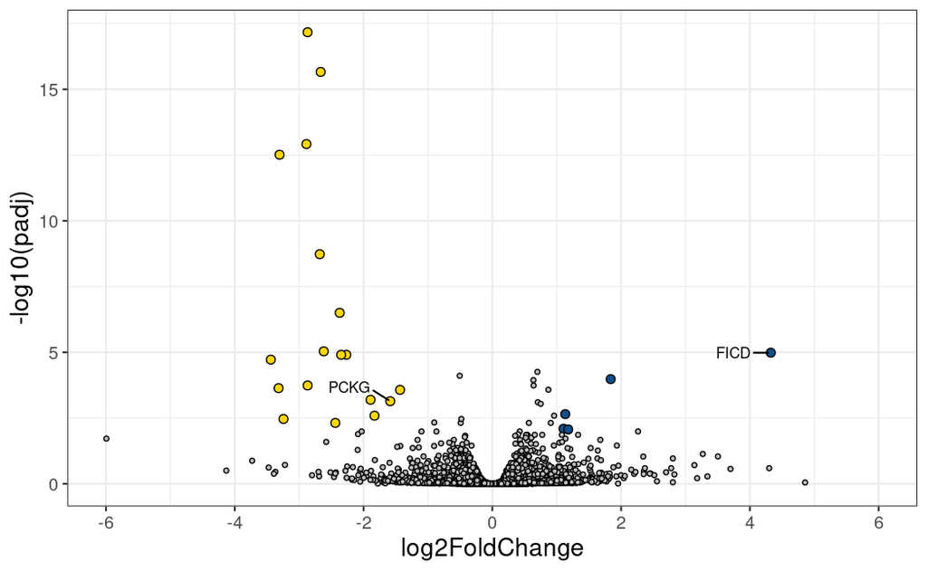

```r
knitr::opts_chunk$set(warning = FALSE, message = FALSE)
#Volcano plot parameters
dds_DMSOvs5AZA_12hrs_filtered$labels <- ifelse(dds_DMSOvs5AZA_12hrs_filtered$Group != "noDifference", T, F)

sizes <- c("downregulated" = 2, "upregulated" = 2, "noDifference" = 1)
alphas <- c("downregulated" = 1, "upregulated" = 1, "noDifference" = 1)

g1 = ggplot(dds_DMSOvs5AZA_12hrs_filtered, aes(x= log2FoldChange,y= -log10(padj),fill=Group,size=Group )) +
  geom_point(shape=21,colour="black")+
  scale_fill_manual(values=c("gold","grey","dodgerblue4")) +
  scale_size_manual(values = sizes) + # Modify point size
  scale_alpha_manual(values = alphas) + # Modify point transparency
  geom_text_repel(aes(x= log2FoldChange,y= -log10(padj)),
                  label = ifelse(dds_DMSOvs5AZA_12hrs_filtered$labels == TRUE,
                                 as.character(dds_DMSOvs5AZA_12hrs_filtered$Dmel),""), #Add fruit fly putative ortholog ID
                  box.padding = unit(.7, "lines"),hjust= 0.30,size=3) +
  scale_x_continuous(breaks = c(seq(-6, 6, 2)), limits = c(-6, 6)) +  theme_bw() +
  theme(legend.position = 'none',axis.text = element_text(size=10),axis.title = element_text(size = 14))
suppressWarnings(grid.arrange(g1))
```

Methylation per DGE gene category - Fig S14B right

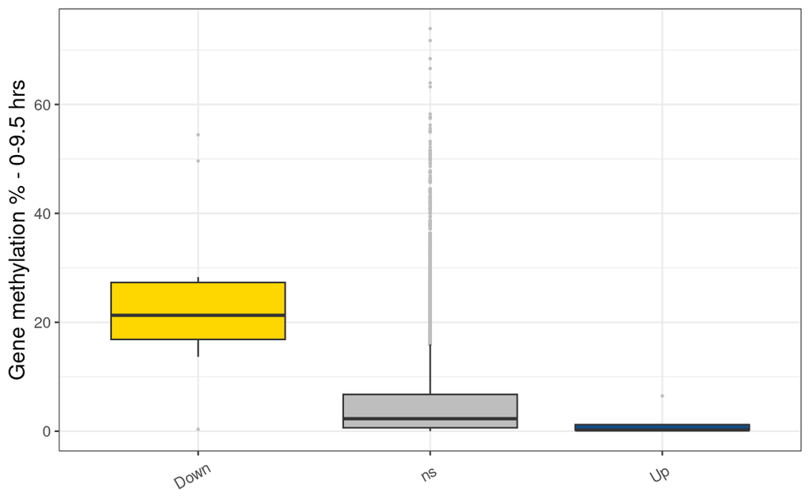

```r
comp_DMSOvs5AZA_12hrs_meth <- merge(dds_DMSOvs5AZA_12hrs_filtered  ,geneBody_full_methData %>% dplyr::select(-c(group,strand)) %>% #sample_n(6000) %>%
        pivot_wider(names_from=class,values_from= c(CpG_N,methylation)) %>%
        dplyr::select(gene,methylation_Cov9hrs:methylation_Cov24hrs),by="gene") %>%
  dplyr::select(gene,Group,`methylation_Cov9hrs`:`methylation_Cov24hrs`) %>%
  pivot_longer(cols = -c(gene,Group),names_to = "stage",values_to="methylation") %>% filter(stage=="methylation_Cov12hrs") %>%
  ggplot(aes(x=Group,y=as.numeric(methylation),fill=Group)) + geom_boxplot(outlier.colour = "grey", outlier.size = 0.4) +
  #geom_jitter(alpha= 0.25,size=0.1,shape=20) +
  scale_x_discrete(labels= c("Down","ns","Up")) +
  scale_y_break(c(40, 95), scales = 0.1, ticklabels=c(95, 100)) + #scale_x_break(c(40,90), scales=2) +
  scale_fill_manual(values=c("gold","grey","dodgerblue4")) + theme_bw()+
  theme(legend.title=element_blank(),axis.text.x = element_text(size = 10,angle =30,vjust = 0.65,hjust = 0.7),
        axis.text.y = element_text(size = 10),legend.position="none",
        axis.title = element_text(size = 14),strip.text.x = element_text(size = 12),
        axis.text.x.top = element_blank(),
        axis.ticks.x.top = element_blank(),
        axis.line.x.top = element_blank()) + xlab(NULL) + ylab("Gene methylation % - 0-9.5 hrs")

#tiff("comp_DMSOvs5AZA_12hrs_plot.tiff", width = 5.3, height = 3.3, units = "in",res = 400,compression = "lzw")
#ggarrange(g1,comp_DMSOvs5AZA_12hrs_meth,widths = c(1,0.6))
#dev.off()
suppressWarnings(grid.arrange(comp_DMSOvs5AZA_12hrs_meth))
```

## 4.2 Comparing embryos treated with DMSO or 5AZA for 12 hrs and sequenced at 24 hrs of development

Create sample table and run DGE

````r
```r
#Create sample table
sampleTable_treated24hrs <- sampleTable %>% filter(condition %in% c('DMSO_24hs','5AZA_24hs'))

dds_treated24hrs <- DESeqDataSetFromMatrix(countData = embryoCounts_allData[,unfactor(sampleTable_treated24hrs$sampleName)], #Change order to match conditions
                                           colData = sampleTable_treated24hrs,
                                           design = ~ condition)

dds_DMSOvs5AZA_24hrs = DESeq(dds_treated24hrs) #Perform Diff expression test

comp_DMSOvs5AZA_24hrs <- results(dds_DMSOvs5AZA_24hrs)
summary(comp_DMSOvs5AZA_24hrs)
````

[output not shown]

[output not shown]

| Group | n |
| --- | --- |
| downregulated | 1981 |
| noDifference | 15401 |
| upregulated | 1679 |

DGE volcano plot - - Fig S14C left

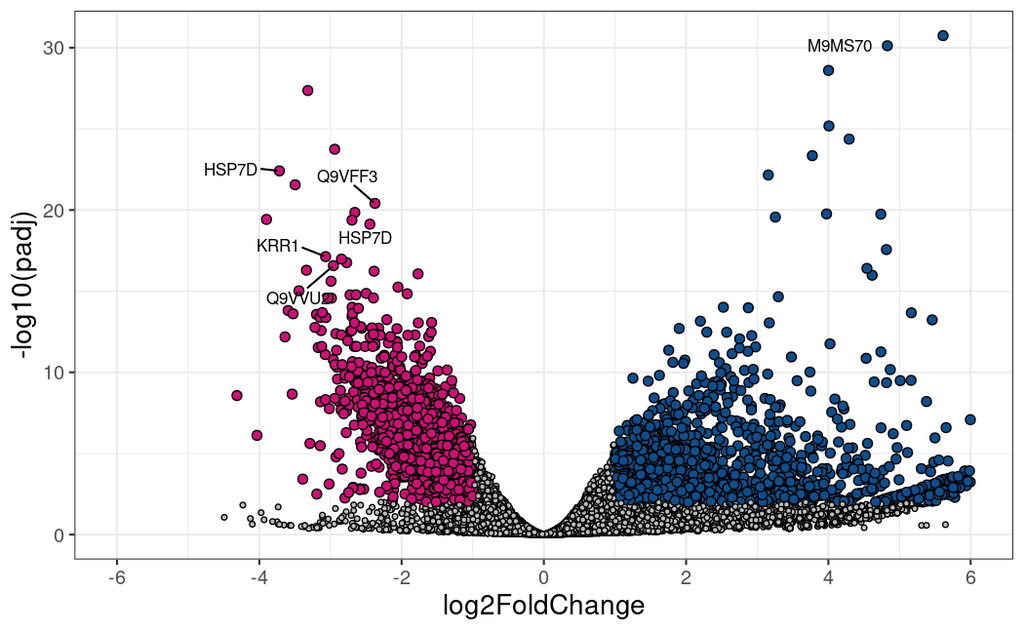

```r
knitr::opts_chunk$set(warning = FALSE, message = FALSE)
#Volcano plot parameters
dds_DMSOvs5AZA_24hrs_filtered$labels <- ifelse(dds_DMSOvs5AZA_24hrs_filtered$Group != "noDifference", T, F)

sizes <- c("downregulated" = 2, "upregulated" = 2, "noDifference" = 1)
alphas <- c("downregulated" = 1, "upregulated" = 1, "noDifference" = 1)

g24 = ggplot(dds_DMSOvs5AZA_24hrs_filtered, aes(x= log2FoldChange,y= -log10(padj),fill=Group,size=Group )) +
  geom_point(shape=21,colour="black")+
  scale_fill_manual(values=c("deeppink3","grey","dodgerblue4")) +
  scale_color_manual(values=c("deeppink3","grey","dodgerblue4")) +
  scale_size_manual(values = sizes) + # Modify point size
  scale_alpha_manual(values = alphas) + # Modify point transparency
  geom_text_repel(aes(x= log2FoldChange,y= -log10(padj)),
                  label = ifelse(dds_DMSOvs5AZA_24hrs_filtered$labels == TRUE,
                                 as.character(dds_DMSOvs5AZA_24hrs_filtered$Dmel),""), #Add fruit fly putative ortholog ID
                  box.padding = unit(.7, "lines"),hjust= 0.30,size=3) +
  scale_x_continuous(breaks = c(seq(-6, 6, 2)), limits = c(-6, 6)) +  theme_bw() +
  theme(legend.position = 'none',axis.text = element_text(size=10),axis.title = element_text(size = 14))
suppressWarnings(grid.arrange(g24))
```

Methylation per DGE gene category - Fig S14C right

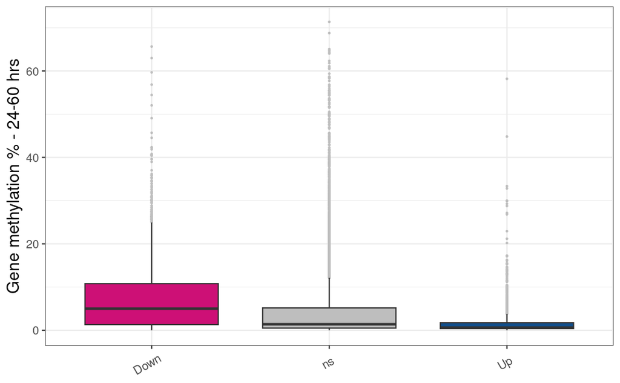

```r
comp_DMSOvs5AZA_24hrs_meth <- merge(dds_DMSOvs5AZA_24hrs_filtered  ,geneBody_full_methData %>% dplyr::select(-c(group,strand)) %>% #sample_n(6000) %>%
        pivot_wider(names_from=class,values_from= c(CpG_N,methylation)) %>%
        dplyr::select(gene,methylation_Cov9hrs:methylation_Cov24hrs),by="gene") %>%
  dplyr::select(gene,Group,`methylation_Cov9hrs`:`methylation_Cov24hrs`) %>%
  pivot_longer(cols = -c(gene,Group),names_to = "stage",values_to="methylation") %>% filter(stage=="methylation_Cov24hrs") %>%
  ggplot(aes(x=Group,y=as.numeric(methylation),fill=Group)) + geom_boxplot(outlier.colour = "grey", outlier.size = 0.4) +
  #geom_jitter(alpha= 0.25,size=0.1,shape=20) +
  scale_x_discrete(labels= c("Down","ns","Up")) +
  scale_y_break(c(40, 95), scales = 0.1, ticklabels=c(95, 100)) + #scale_x_break(c(40,90), scales=2) +
  scale_fill_manual(values=c("deeppink3","grey","dodgerblue4")) + theme_bw()+
  theme(legend.title=element_blank(),axis.text.x = element_text(size = 10,angle =30,vjust = 0.65,hjust = 0.7),
        axis.text.y = element_text(size = 10),legend.position="none",
        axis.title = element_text(size = 14),strip.text.x = element_text(size = 12),
        axis.text.x.top = element_blank(),
        axis.ticks.x.top = element_blank(),
        axis.line.x.top = element_blank()) + xlab(NULL) + ylab("Gene methylation % - 24-60 hrs")

# tiff("comp_DMSOvs5AZA_24hrs_plot.tiff", width = 5.3, height = 3.3, units = "in",res = 400,compression = "lzw")
# ggarrange(g24,comp_DMSOvs5AZA_24hrs_meth,widths = c(1,0.4))
# dev.off()
suppressWarnings(grid.arrange(comp_DMSOvs5AZA_24hrs_meth))
```

Relationship between methylation and DGE FC for downregulated genes - Fig 6C

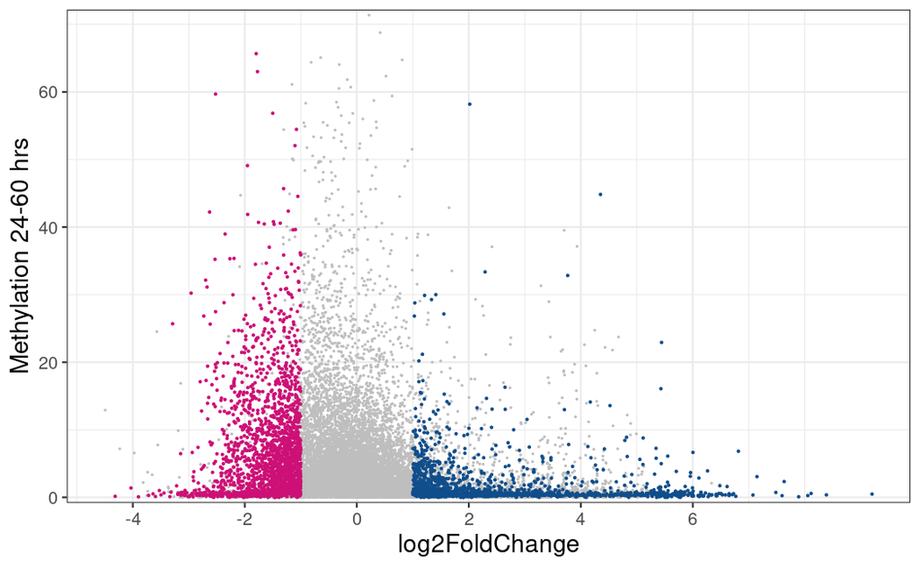

```r
temp_data_MethExp <- merge(dds_DMSOvs5AZA_24hrs_filtered,geneBody_full_methData %>% dplyr::select(-c(group,strand)) %>%
                             pivot_wider(names_from=class,values_from= c(CpG_N,methylation)) %>%
                             dplyr::select(gene,methylation_Cov9hrs:methylation_Cov24hrs),by="gene",all.x=T) %>% tibble() %>%
  mutate(Group2=factor(Group, levels= c("noDifference","upregulated" ,"downregulated"))) %>% arrange(Group2) %>% data.frame()

temp_data_MethExp$labels <- ifelse(temp_data_MethExp$Group != "noDifference", T, F)
temp_data_MethExp$labelsTF <- ifelse((temp_data_MethExp$Group != "noDifference" &
                                        temp_data_MethExp$class == "TF"), T, F)

sizes <- c("downregulated" = 0.3, "upregulated" = 0.3, "noDifference" = 0.12)

g5 <- temp_data_MethExp %>% ggplot(aes(x=log2FoldChange,y=`methylation_Cov24hrs`,fill=Group2,colour=Group2,size=Group2,alpha=Group2)) +
  geom_point(shape=21)+#,colour="white")+
  scale_fill_manual(values=c("grey","dodgerblue4","deeppink3")) +
  scale_color_manual(values=c("grey","dodgerblue4","deeppink3")) +
  scale_size_manual(values = sizes) + # Modify point size
  scale_alpha_manual(values = alphas) + # Modify point transparency
  scale_x_continuous(breaks = c(seq(-6, 6, 2))) + scale_y_continuous(expand = c(0.01,0.1)) +
  theme_bw()+ ylab("Methylation 24-60 hrs") +
  theme(legend.position = 'none',axis.text = element_text(size=10),axis.title = element_text(size = 14))

# tiff("AZA24hrs_FCvsMethyl_plot.tiff", width = 2.3, height = 4.3, units = "in",res = 400,compression = "lzw")
# g5
# dev.off()
suppressWarnings(grid.arrange(g5))
```